# Untitled

Vivian Lu

4/14/2019

# 1.0: Raw Data Loading

Load data that was downloaded from Figure8

```r
raw <- read.csv('combined_scores_by_worker.csv', sep=',', header=TRUE)
full_raw <- read.csv('combined_raw_data_nodrop_20190407.csv', sep=',', header=TRUE)
```

# 2.0: Manipulation

Insert worker trust characteristic from Figure8

```r
trust_df <- unique(full_raw[,c('X_worker_id','X_trust')])
raw_merged = merge(raw, trust_df)
```

## 2.1 Summary stats

This entire section of code explains how the summary statistics were calculated:

*Basic statistics*: Average scores and trusts (with standard deviations) by experiment group.

```r
# TOTAL N
control <- raw_merged[raw_merged['treatment']=='control',] #75 people
publicgood <- raw_merged[raw_merged['treatment']=='publicgood',] #122 people
evaluation <- raw_merged[raw_merged['treatment']=='evaluation',] #86 people

# AVERAGE SCORES AND STANDARD DEVIATIONS OF SCORES IN EACH BRANCH OF EXPERIMENT
control_avg <- mean(control[,'score'])
publicgood_avg <- mean(publicgood[,'score'])
evaluation_avg <- mean(evaluation[,'score'])

control_sd <-sd(control[,'score'])
publicgood_sd <- sd(publicgood[,'score'])
evaluation_sd <- sd(evaluation[,'score'])

# AVERAGE TRUST SCORES AND STANDARD DEVIATIONS OF TRUST SCORES IN EACH BRANCH OF EXPERIMENT
control_trust <- mean(control[,'X_trust'])
publicgood_trust <- mean(publicgood[,'X_trust'])
evaluation_trust <- mean(evaluation[,'X_trust'])

control_trust_sd <- sd(control[,'X_trust'])
publicgood_trust_sd<-sd(publicgood[,'X_trust'])
evaluation_trust_sd<-sd(evaluation[,'X_trust'])

avg_vector <- c(control_avg, publicgood_avg, evaluation_avg)
sd_vector <- c(control_sd, publicgood_sd, evaluation_sd)
avg_trust_vector<-c(control_trust, publicgood_trust, evaluation_trust)
sd_trust_vector<-c(control_trust_sd, publicgood_trust_sd, evaluation_trust_sd)
average_df <- data.frame(avg_vector, sd_vector,avg_trust_vector, sd_trust_vector,row.names=c('control','publicgood','evaluation'))
colnames(average_df)<-c('average_score', 'stdev_score','avg_trust','sd_trust')

# average_df holds the summary stats for all 3 groups

average_df
```

```
##            average_score stdev_score avg_trust   sd_trust
## control        0.9345734   0.1232120 0.9768893 0.11206786
## publicgood     0.9091946   0.1422645 0.9592049 0.11535046
## evaluation     0.9046028   0.1407317 0.9841081 0.09242291
```

*Within groups*: There are people who received compliance questions, in which you could answer correctly or incorrectly. Those who get compliance questions correct are the ‘compliers’ and those who did not get compliance questions are the ‘non-compliers’.

Below, we get a sense of how the proportion of compliers (amongst those who got compliance questions)

```r
get_compliers <- function(df, trtmt) {
  subdf <- df[df['treatment']==trtmt & df['label']=='Snail',] #received Snail question
  contributors <- unique(subdf[,'X_worker_id']) #get workers
  compliance_score <- c()
  trust_vector<-c()
  for (i in 1:length(contributors)) {
    v<-mean(subdf[subdf['X_worker_id']==contributors[i],][,'correct'])
    compliance_score[i]<-v
    # get trust
    t<-subdf[subdf['X_worker_id']==contributors[i],][,'X_trust'][1]
    trust_vector[i]<-t
  }
  return(data.frame(contributors, compliance_score, trust_vector))
}

# total compliers
control_compliers<-get_compliers(full_raw, 'control')
publicgood_compliers<-get_compliers(full_raw,'publicgood')
evaluation_compliers<-get_compliers(full_raw,'evaluation')

total_compliance<-c(dim(control_compliers)[1], dim(publicgood_compliers)[1],dim(evaluation_compliers)[1])
actual_compliers<-c(dim(control_compliers[control_compliers['compliance_score']>0,])[1], dim(publicgood_compliers[publicgood_compliers['compliance_score']>0,])[1], dim(evaluation_compliers[evaluation_compliers['compliance_score']>0,])[1])
prop_compliers<-actual_compliers/total_compliance
compliers_df<-data.frame(total_compliance,actual_compliers, prop_compliers, row.names=c('control','publicgood','evaluation'))

# compliers_df: shows the number of compliers in each experiment group as well as the total who answered the compliance question correctly.

compliers_df
```

```
##            total_compliance actual_compliers prop_compliers
## control                  37               28      0.7567568
## publicgood               52               39      0.7500000
## evaluation               45               34      0.7555556
```

For those who did get the compliance question, was there anything differing amongst compliers vs noncompliers to suggest that they would be different? We look at `trust`, a score that Figure8 provides for test administrators to judge how ‘trustworthy’ a contributor is.

```r
get_avg_comply_trust <- function(df){
  avg_comply<-mean(df[df['compliance_score']>0,][,'trust_vector'])
  return(avg_comply)
}

get_avg_noncomply_trust <- function(df){
  avg_noncomply<-mean(df[df['compliance_score']==0,][,'trust_vector'])
  return(avg_noncomply)
}

get_sd_comply_trust <- function(df){
  sd_comply<-sd(df[df['compliance_score']>0,][,'trust_vector'])
  return(sd_comply)
}

get_sd_noncomply_trust <- function(df){
  sd_noncomply<-sd(df[df['compliance_score']==0,][,'trust_vector'])
  return(sd_noncomply)
}

trust_avgs<-c(get_avg_comply_trust(control_compliers), get_avg_comply_trust(publicgood_compliers), get_avg_comply_trust(evaluation_compliers))
trust_noncompliers_avgs<-c(get_avg_noncomply_trust(control_compliers), get_avg_noncomply_trust(publicgood_compliers), get_avg_noncomply_trust(evaluation_compliers))
trust_sds<-c(get_sd_comply_trust(control_compliers), get_sd_comply_trust(publicgood_compliers), get_sd_comply_trust(evaluation_compliers))
trust_noncompliers_sds<-c(get_sd_noncomply_trust(control_compliers), get_sd_noncomply_trust(publicgood_compliers), get_sd_noncomply_trust(evaluation_compliers))

compliers_df['complier_trust_avgs']<-trust_avgs
compliers_df['complier_trust_sds']<-trust_sds
compliers_df['noncomplier_trust_avgs']<-trust_noncompliers_avgs
compliers_df['noncomplier_trust_sds']<-trust_noncompliers_sds

compliers_df
```

```
##            total_compliance actual_compliers prop_compliers
## control                  37               28      0.7567568
## publicgood               52               39      0.7500000
## evaluation               45               34      0.7555556
##            complier_trust_avgs complier_trust_sds noncomplier_trust_avgs
## control              0.9666679         0.10511546              1.0000000
## publicgood           0.9465795         0.13817718              0.9748538
## evaluation           0.9950971         0.02858881              1.0000000
##            noncomplier_trust_sds
## control               0.00000000
## publicgood            0.07082451
## evaluation            0.00000000
```

For those who did get compliance questions vs. those who did not get compliance questions: Was this a selection bias by Figure8?

```r
get_nocompl_q <- function(df, trtmt) {
  subdf <- df[df['treatment']==trtmt & df['label']!='Snail',]
  contributors <- unique(subdf[,'X_worker_id'])
  trust_vector<-c()
  for (i in 1:length(contributors)) {
    # get trust
    t<-subdf[subdf['X_worker_id']==contributors[i],][,'X_trust'][1]
    trust_vector[i]<-t
  }
  return(data.frame(contributors, trust_vector))
}

nocompl_q_control<-get_nocompl_q(full_raw,'control')
nocompl_q_publicgood<-get_nocompl_q(full_raw,'publicgood')
nocompl_q_evaluation<-get_nocompl_q(full_raw,'evaluation')

nocompl_q_avg<-c(mean(nocompl_q_control[['trust_vector']]),mean(nocompl_q_publicgood[['trust_vector']]),mean(nocompl_q_evaluation[['trust_vector']]))
nocompl_q_std<-c(sd(nocompl_q_control[['trust_vector']]),sd(nocompl_q_publicgood[['trust_vector']]),sd(nocompl_q_evaluation[['trust_vector']]))
nocompl_df<-data.frame(nocompl_q_avg, nocompl_q_std, row.names=c('control','publicgood','evaluation'))

compl_q_avg<-c(mean(control_compliers[['trust_vector']]),mean(publicgood_compliers[['trust_vector']]),mean(evaluation_compliers[['trust_vector']]))
compl_q_std<-c(sd(control_compliers[['trust_vector']]),sd(publicgood_compliers[['trust_vector']]),sd(evaluation_compliers[['trust_vector']]))
compl_df<-data.frame(compl_q_avg, compl_q_std, row.names=c('control','publicgood','evaluation'))


print('No Compliance Question: Trust Characteristics By Group')
```

```
## [1] "No Compliance Question: Trust Characteristics By Group"
```

```r
nocompl_df
```

```
##            nocompl_q_avg nocompl_q_std
## control        0.9768893    0.11206786
## publicgood     0.9592049    0.11535046
## evaluation     0.9841081    0.09242291
```

```r
print('Compliance Question: Trust Characteristics By Group')
```

```
## [1] "Compliance Question: Trust Characteristics By Group"
```

```r
compl_df
```

```
##            compl_q_avg compl_q_std
## control      0.9747757  0.09217993
## publicgood   0.9536481  0.12473653
## evaluation   0.9962956  0.02485017
```

*Breakdown of scores for those who did and did not receive compliance questions:*

```r
##### CONTROL
yes_q<-control_compliers[,'contributors']
no_q<-setdiff(raw_merged[raw_merged['treatment']=='control','X_worker_id'],control_compliers[,'contributors'])

c_yes_avg_score<-mean(raw_merged[(raw_merged$treatment=='control') & (raw_merged$X_worker_id %in% yes_q),'score'])
c_yes_sd_score<-sd(raw_merged[(raw_merged$treatment=='control') & (raw_merged$X_worker_id %in% yes_q),'score'])
c_no_avg_score<-mean(raw_merged[(raw_merged$treatment=='control') & (raw_merged$X_worker_id %in% no_q),'score'])
c_no_sd_score<-sd(raw_merged[(raw_merged$treatment=='control') & (raw_merged$X_worker_id %in% no_q),'score'])


#### PUBLICGOOD

yes_q<-publicgood_compliers[,'contributors']
no_q<-setdiff(raw_merged[raw_merged['treatment']=='publicgood','X_worker_id'],publicgood_compliers[,'contributors'])

p_yes_avg_score<-mean(raw_merged[(raw_merged$treatment=='publicgood') & (raw_merged$X_worker_id %in% yes_q),'score'])
p_yes_sd_score<-sd(raw_merged[(raw_merged$treatment=='publicgood') & (raw_merged$X_worker_id %in% yes_q),'score'])
p_no_avg_score<-mean(raw_merged[(raw_merged$treatment=='publicgood') & (raw_merged$X_worker_id %in% no_q),'score'])
p_no_sd_score<-sd(raw_merged[(raw_merged$treatment=='publicgood') & (raw_merged$X_worker_id %in% no_q),'score'])

#### EVALUATION

yes_q<-evaluation_compliers[,'contributors']
no_q<-setdiff(raw_merged[raw_merged['treatment']=='evaluation','X_worker_id'],evaluation_compliers[,'contributors'])

e_yes_avg_score<-mean(raw_merged[(raw_merged$treatment=='evaluation') & (raw_merged$X_worker_id %in% yes_q),'score'])
e_yes_sd_score<-sd(raw_merged[(raw_merged$treatment=='evaluation') & (raw_merged$X_worker_id %in% yes_q),'score'])
e_no_avg_score<-mean(raw_merged[(raw_merged$treatment=='evaluation') & (raw_merged$X_worker_id %in% no_q),'score'])
e_no_sd_score<-sd(raw_merged[(raw_merged$treatment=='evaluation') & (raw_merged$X_worker_id %in% no_q),'score'])

#### Combine together

received_q_avg<-c(c_yes_avg_score, p_yes_avg_score, e_yes_avg_score)
received_q_sd<-c(c_yes_sd_score, p_yes_sd_score, e_yes_sd_score)
noreceived_q_avg<-c(c_no_avg_score, p_no_avg_score, e_no_avg_score)
noreceived_q_sd<-c(c_no_sd_score, p_no_sd_score, e_no_sd_score)

scores_complynocomply_df<-data.frame(received_q_avg, received_q_sd, noreceived_q_avg, noreceived_q_sd, row.names = c('control','publicgood','evaluation'))
scores_complynocomply_df
```

```
##            received_q_avg received_q_sd noreceived_q_avg noreceived_q_sd
## control         0.8890000    0.09840124        0.9789474       0.1297771
## publicgood      0.8436874    0.15915576        0.9578571       0.1055131
## evaluation      0.8510188    0.12222565        0.9634146       0.1373974
```

*Breakdown of scores for those who DID answer compliance questions correctly given that they were offered a compliance question:*

```r
##### CONTROL
correct_comply <- control_compliers[control_compliers$compliance_score>0,'contributors']
wrong_comply <- control_compliers[control_compliers$compliance_score==0,'contributors']
# get scores
c_correct_avg<-mean(raw_merged[(raw_merged$treatment=='control') & (raw_merged$X_worker_id %in% correct_comply),'score'])
c_correct_sd<-sd(raw_merged[(raw_merged$treatment=='control') & (raw_merged$X_worker_id %in% correct_comply),'score'])
c_wrong_avg<-mean(raw_merged[(raw_merged$treatment=='control') & (raw_merged$X_worker_id %in% wrong_comply),'score'])
c_wrong_sd<-sd(raw_merged[(raw_merged$treatment=='control') & (raw_merged$X_worker_id %in% wrong_comply),'score'])

#### PUBLICGOOD
correct_comply <- publicgood_compliers[publicgood_compliers$compliance_score>0,'contributors']
wrong_comply <- publicgood_compliers[publicgood_compliers$compliance_score==0,'contributors']
# get scores
p_correct_avg<-mean(raw_merged[(raw_merged$treatment=='publicgood') & (raw_merged$X_worker_id %in% correct_comply),'score'])
p_correct_sd<-sd(raw_merged[(raw_merged$treatment=='publicgood') & (raw_merged$X_worker_id %in% correct_comply),'score'])
p_wrong_avg<-mean(raw_merged[(raw_merged$treatment=='publicgood') & (raw_merged$X_worker_id %in% wrong_comply),'score'])
p_wrong_sd<-sd(raw_merged[(raw_merged$treatment=='publicgood') & (raw_merged$X_worker_id %in% wrong_comply),'score'])

#### EVALUATION
correct_comply <- evaluation_compliers[evaluation_compliers$compliance_score>0,'contributors']
wrong_comply <- evaluation_compliers[evaluation_compliers$compliance_score==0,'contributors']
# get scores
e_correct_avg<-mean(raw_merged[(raw_merged$treatment=='evaluation') & (raw_merged$X_worker_id %in% correct_comply),'score'])
e_correct_sd<-sd(raw_merged[(raw_merged$treatment=='evaluation') & (raw_merged$X_worker_id %in% correct_comply),'score'])
e_wrong_avg<-mean(raw_merged[(raw_merged$treatment=='evaluation') & (raw_merged$X_worker_id %in% wrong_comply),'score'])
e_wrong_sd<-sd(raw_merged[(raw_merged$treatment=='evaluation') & (raw_merged$X_worker_id %in% wrong_comply),'score'])

# Combine together

correct_comply_avg<-c(c_correct_avg, p_correct_avg, e_correct_avg)
correct_comply_sd<-c(c_correct_sd, p_correct_sd, e_correct_sd)
wrong_comply_avg<-c(c_wrong_avg, p_wrong_avg, e_wrong_avg)
wrong_comply_sd<-c(c_wrong_sd, p_wrong_sd, e_wrong_sd)

scores_receivedcomply_df<-data.frame(correct_comply_avg, correct_comply_sd, wrong_comply_avg, wrong_comply_sd, row.names = c('control','publicgood','evaluation'))
scores_receivedcomply_df
```

```
##            correct_comply_avg correct_comply_sd wrong_comply_avg
## control             0.9110596        0.09171880        0.8203704
## publicgood          0.8965690        0.12485538        0.6850427
## evaluation          0.8919926        0.08663272        0.7243723
##            wrong_comply_sd
## control         0.09043789
## publicgood      0.14810852
## evaluation      0.13271572
```

In total, those who received compliance questions in our experiment = 134 people, which is nearly a 50% decrease from our original sample size of 283.

# 3.0 2SLS regression

We want to know the average treatment effect amongst compliers (p. 150 in text)

*Manipulation of column indicators below*:

```r
# get those who did get compliance questions into 1 dataframe
# control_compliers, publicgood_compliers, evaluation_compliers

# make a column that indicates what group the complier was from
control_compliers['treatment']=rep('control', dim(control_compliers)[1])
publicgood_compliers['treatment']=rep('publicgood', dim(publicgood_compliers)[1])
evaluation_compliers['treatment']=rep('evaluation', dim(evaluation_compliers)[1])

all_compl_q_workers<-rbind(control_compliers, publicgood_compliers, evaluation_compliers)

received_compliance_q<-c()
# go through each row of raw_merged and match based on worker_id and treatment
for (i in 1:dim(raw_merged)[1]) {
  worker <- raw_merged[i,'X_worker_id']
  grp <- levels(raw_merged[i,'treatment'])[levels(raw_merged[i,'treatment'])==raw_merged[i,'treatment']]
  l<-all_compl_q_workers[(all_compl_q_workers['contributors']==worker) & (all_compl_q_workers['treatment']==grp),]
  if (dim(l)[1]>0){
    # worker received compliance Q
    received_compliance_q[i]<-1
  } else {
    # worker did not receive compliance Q
    received_compliance_q[i]<-0
  }
}
raw_merged['received_compliance_q']<-received_compliance_q
```

At this point, drop those who did not get compliance q (received_compliance_q == 0)

```r
only_received_compl_q <- raw_merged[raw_merged['received_compliance_q']==1,]
# left with 134 people
```

Finally, we merge compliance scores for those who received compliance questions. Given that you received a compliance question (‘received_compliance_q’==`), you get 1 if you answered correctly, and 0 if answered incorrectly.

```r
all_compl_q_workers['complied']<-ifelse(all_compl_q_workers[,'compliance_score']>0,1,0)
colnames(all_compl_q_workers)<-c('X_worker_id','compliance_score','trust_vector','treatment','complied')

# Merge onto only_received_compl_q based on 2 indexes: X_worker_id, treatment

df_final<-merge(all_compl_q_workers, only_received_compl_q, by.y=c('X_worker_id','treatment'))
```

Finally, for easier viewing, we make a percent transformation of the original score.

```r
df_final['pct_score']=df_final['score']*100
```

## 3.1 1st stage of 2SLS

Regress outcome on assigned treatment

```r
library(lmtest)
library(sandwich)

# Keep in mind: this is amongst people who DID get compliance questions
# treatment is a column that indicates the assigned group (control, evaluation, publicgood)
# pct_score is our outcome variable (percentage points )

# this is equivalent to just difference in means estimator (ITT)
itt_fit<-lm(pct_score ~ treatment, data=df_final)
coeftest(itt_fit, vcovHC(itt_fit))
```

```
##
## t test of coefficients:
##
##                     Estimate Std. Error t value Pr(>|t|)
## (Intercept)          88.9000     1.6400 54.2066   <2e-16 ***
## treatmentevaluation  -3.7981     2.4668 -1.5397   0.1260
## treatmentpublicgood  -4.5313     2.7670 -1.6376   0.1039
## ---
## Signif. codes:  0 '***' 0.001 '**' 0.01 '*' 0.05 '.' 0.1 ' ' 1
```

## 3.2 2nd stage of 2SLS

Regress actual treatment on assigned treatment.

```r
# Treatment received (The actual treatment) is whether or not you read the instructions (which is determined by whether or not you got the compliance question right)

itt_d_fit<-lm(complied ~ treatment, data=df_final)
coeftest(itt_d_fit, vcovHC(itt_d_fit))
```

```
##
## t test of coefficients:
##
##                       Estimate Std. Error t value Pr(>|t|)
## (Intercept)          0.7567568  0.0724931 10.4390   <2e-16 ***
## treatmentevaluation -0.0012012  0.0977148 -0.0123   0.9902
## treatmentpublicgood -0.0067568  0.0948884 -0.0712   0.9433
## ---
## Signif. codes:  0 '***' 0.001 '**' 0.01 '*' 0.05 '.' 0.1 ' ' 1
```

Notice how we have 2 ITT_d

## 3.3 Randomization Inference to obtain Confidence Intervals

First, let’s save the ITT_d numbers for each treatment

```r
itt_d_eval<-coeftest(itt_d_fit, vcovHC(itt_d_fit))[,1][[1]]+coeftest(itt_d_fit, vcovHC(itt_d_fit))[,1][[2]]
itt_d_publicgood<-coeftest(itt_d_fit, vcovHC(itt_d_fit))[,1][[1]]+coeftest(itt_d_fit, vcovHC(itt_d_fit))[,1][[3]]
```

Below, we can grab the estimates of ITT_hat.

```r
# This is simply the impact of assignment
ITT_hat_control<-coeftest(itt_fit, vcovHC(itt_fit))[,1][[1]] #technically we won't look at this
ITT_hat_evaluation<-coeftest(itt_fit, vcovHC(itt_fit))[,1][[2]] # -0.0379
ITT_hat_publicgood<-coeftest(itt_fit, vcovHC(itt_fit))[,1][[3]] # -0.0453
```

To get the standard error of ITT_hat, we use randomization inference. You shuffle treatment column (control, publicgood, evaluation), and get 2 possible distributions of calculated ITT_hat (one for each treatment branch). From there, we can gather the standard error from the calculated ITT_hats.

```r
randomization_inf_SE_ITT_hat <- function(df){
  copy_df <- df[,c('treatment','pct_score')]
  shuffle_order<-sample(nrow(copy_df))
  copy_df['adj_treatment']<-copy_df[,'treatment'][shuffle_order]
  modfit<-lm(pct_score ~ adj_treatment, data=copy_df)
  return(coeftest(modfit, vcovHC(modfit)))
}

get_SE_ITT <- function(rep_n){
  #rep_n has no meaning here, it's just a holder
  output <- randomization_inf_SE_ITT_hat(df_final)
  rep_itt_control<-output[,1][[1]]
  rep_itt_eval<-output[,1][[2]]
  rep_itt_publicgood<-output[,1][[3]]
  return(c(rep_itt_control, rep_itt_eval, rep_itt_publicgood))
}

itt_simul_control<-c()
itt_simul_eval<-c()
itt_simul_publicgood<-c()
for (i in 1:10000) {
  output_row<-get_SE_ITT(1)
  itt_simul_control[i]<-output_row[1]
  itt_simul_eval[i]<-output_row[2]
  itt_simul_publicgood[i]<-output_row[3]
}

itt_simulation_compl_q<-data.frame(itt_simul_control, itt_simul_eval, itt_simul_publicgood)
```

We can get the estimated standard error of our ITT_hat estimates below:

```r
SE_ITThat_control<-sd(itt_simulation_compl_q$itt_simul_control)
SE_ITThat_eval<-sd(itt_simulation_compl_q$itt_simul_eval)
SE_ITThat_publicgood<-sd(itt_simulation_compl_q$itt_simul_publicgood)
print('Estimated SE(ITT_hat): control, evaluation, publicgood')
```

```
## [1] "Estimated SE(ITT_hat): control, evaluation, publicgood"
```

```r
c(SE_ITThat_control, SE_ITThat_eval, SE_ITThat_publicgood)
```

```
## [1] 1.878067 2.963216 2.890851
```

Thus, we can calculate a 95% confidence interval for our ITT_hat of the 2 treatment groups (public good and evaluation)

```r
print('ITT_hat eval confidence interval')
```

```
## [1] "ITT_hat eval confidence interval"
```

```r
c(ITT_hat_evaluation-(1.96*SE_ITThat_eval),ITT_hat_evaluation+(1.96*SE_ITThat_eval))
```

```
## [1] -9.606030  2.009774
```

```r
print('ITT_hat_publicgood confidence interval')
```

```
## [1] "ITT_hat_publicgood confidence interval"
```

```r
c(ITT_hat_publicgood-(1.96*SE_ITThat_publicgood), ITT_hat_publicgood+(1.96*SE_ITThat_publicgood))
```

```
## [1] -10.197329   1.134806
```

An interesting point of note: Let’s take a look at the distributions of our simulated ITT_hats.

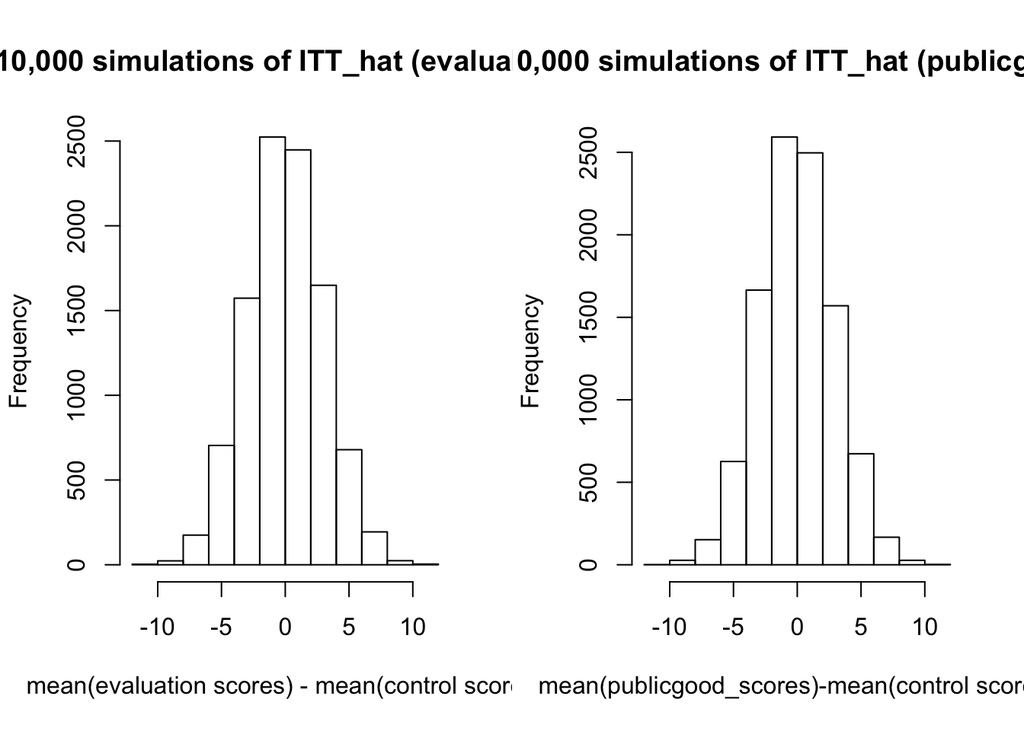

```r
par(mfrow=c(1,2))
# simulated ITT_hats for evaluation treatment
hist(itt_simulation_compl_q$itt_simul_eval, main='10,000 simulations of ITT_hat (evaluation)', xlab='mean(evaluation scores) - mean(control scores)')

# simulated ITT_hats for publicgood treatment
hist(itt_simulation_compl_q$itt_simul_publicgood, main='10,000 simulations of ITT_hat (publicgood)', xlab='mean(publicgood_scores)-mean(control scores)')
```

We can calculate the p-value of our obtained ITT difference in each treatment branch.

```r
# calculate single p-value
print('simulated p-value for current ITT_hat of evaluation treatment')
```

```
## [1] "simulated p-value for current ITT_hat of evaluation treatment"
```

```r
length(itt_simulation_compl_q$itt_simul_eval[itt_simulation_compl_q$itt_simul_eval < -3.7981])/10000
```

```
## [1] 0.1019
```

```r
print('simulated p-value for current ITT_hat of publicgood treatment')
```

```
## [1] "simulated p-value for current ITT_hat of publicgood treatment"
```

```r
length(itt_simulation_compl_q$itt_simul_publicgood[itt_simulation_compl_q$itt_simul_publicgood < -4.5313])/10000
```

```
## [1] 0.0547
```

## 3.4 CACE

CACE is just ITT_hat divided by ITT_d:

```r
print('CACE_eval point estimate')
```

```
## [1] "CACE_eval point estimate"
```

```r
CACE_eval<-ITT_hat_evaluation/(itt_d_eval)
CACE_eval
```

```
## [1] -5.026934
```

```r
print('CACE_publicgood point estimate')
```

```
## [1] "CACE_publicgood point estimate"
```

```r
CACE_publicgood<-ITT_hat_publicgood/(itt_d_publicgood)
CACE_publicgood
```

```
## [1] -6.041682
```

We can also calculate a confidence interval for our CACE estimate:

```r
SE_CACE_eval<-SE_ITThat_eval/itt_d_eval
SE_CACE_publicgood<-SE_ITThat_publicgood/itt_d_publicgood

print('CI of CACE evaluation')
```

```
## [1] "CI of CACE evaluation"
```

```r
c(CACE_eval-(1.96*SE_CACE_eval), CACE_eval+(1.96*SE_CACE_eval))
```

```
## [1] -12.713864   2.659996
```

```r
print('CI of CACE publicgood')
```

```
## [1] "CI of CACE publicgood"
```

```r
c(CACE_publicgood-(1.96*SE_CACE_publicgood), CACE_publicgood+(1.96*SE_CACE_publicgood))
```

```
## [1] -13.596438   1.513074
```

# 4.0 Checking for Repeaters

We note that there are definitely some repeaters (people who took more than 1 test). There is not a known way of preventing contributors from taking multiple tests on the platform Figure8. Contributors themselves log on and take tests as they see fit.

```r
length(intersect(unique(control[['X_worker_id']]),unique(publicgood[['X_worker_id']]))) #10
```

```
## [1] 10
```

```r
length(intersect(unique(control[['X_worker_id']]),unique(evaluation[['X_worker_id']]))) #7
```

```
## [1] 7
```

```r
length(intersect(unique(publicgood[['X_worker_id']]),unique(evaluation[['X_worker_id']]))) #23
```

```
## [1] 23
```

In total, it looks like there are 40 repeaters.

Our original summary stats were for everyone.

Let’s break it down to summary stats for all non-repeaters:

```r
repeaters<-c(intersect(unique(control[['X_worker_id']]),unique(publicgood[['X_worker_id']])), intersect(unique(control[['X_worker_id']]),unique(evaluation[['X_worker_id']])), intersect(unique(publicgood[['X_worker_id']]),unique(evaluation[['X_worker_id']])))

full_merged<-read.csv('combined_full_workers_final_20190414.csv')
nonrepeaters<-full_merged[!full_merged$X_worker_id %in% repeaters,]
```

Basic stats:

```r
# TOTAL N
r_control <- nonrepeaters[nonrepeaters['treatment']=='control',] #61 people
r_publicgood <- nonrepeaters[nonrepeaters['treatment']=='publicgood',] #92 people
r_evaluation <- nonrepeaters[nonrepeaters['treatment']=='evaluation',] #59 people

# AVERAGE SCORES AND STANDARD DEVIATIONS OF SCORES IN EACH BRANCH OF EXPERIMENT
r_control_avg <- mean(r_control[,'score'])
r_publicgood_avg <- mean(r_publicgood[,'score'])
r_evaluation_avg <- mean(r_evaluation[,'score'])

r_control_sd <-sd(r_control[,'score'])
r_publicgood_sd <- sd(r_publicgood[,'score'])
r_evaluation_sd <- sd(r_evaluation[,'score'])

# AVERAGE TRUST SCORES AND STANDARD DEVIATIONS OF TRUST SCORES IN EACH BRANCH OF EXPERIMENT
r_control_trust <- mean(r_control[,'X_trust'])
r_publicgood_trust <- mean(r_publicgood[,'X_trust'])
r_evaluation_trust <- mean(r_evaluation[,'X_trust'])

r_control_trust_sd <- sd(r_control[,'X_trust'])
r_publicgood_trust_sd<-sd(r_publicgood[,'X_trust'])
r_evaluation_trust_sd<-sd(r_evaluation[,'X_trust'])

r_avg_vector <- c(r_control_avg, r_publicgood_avg, r_evaluation_avg)
r_sd_vector <- c(r_control_sd, r_publicgood_sd, r_evaluation_sd)
r_avg_trust_vector<-c(r_control_trust, r_publicgood_trust, r_evaluation_trust)
r_sd_trust_vector<-c(r_control_trust_sd, r_publicgood_trust_sd, r_evaluation_trust_sd)
r_average_df <- data.frame(r_avg_vector, r_sd_vector,r_avg_trust_vector, r_sd_trust_vector,row.names=c('control','publicgood','evaluation'))
colnames(r_average_df)<-c('average_score', 'stdev_score','avg_trust','sd_trust')

# r_average_df holds the summary stats for all 3 groups

r_average_df
```

```
##            average_score stdev_score avg_trust  sd_trust
## control        0.9315793   0.1299931 0.9715852 0.1238405
## publicgood     0.9158126   0.1323239 0.9567022 0.1192631
## evaluation     0.8978916   0.1535688 0.9796610 0.1095125
```

```r
nonrepeaters_fullraw<-full_raw[!full_raw$X_worker_id %in% repeaters,]

# total compliers
r_control_compliers<-get_compliers(nonrepeaters_fullraw, 'control')
r_publicgood_compliers<-get_compliers(nonrepeaters_fullraw,'publicgood')
r_evaluation_compliers<-get_compliers(nonrepeaters_fullraw,'evaluation')

r_total_compliance<-c(dim(r_control_compliers)[1], dim(r_publicgood_compliers)[1],dim(r_evaluation_compliers)[1])
r_actual_compliers<-c(dim(r_control_compliers[r_control_compliers['compliance_score']>0,])[1], dim(r_publicgood_compliers[r_publicgood_compliers['compliance_score']>0,])[1], dim(r_evaluation_compliers[r_evaluation_compliers['compliance_score']>0,])[1])
r_prop_compliers<-r_actual_compliers/r_total_compliance
r_compliers_df<-data.frame(r_total_compliance,r_actual_compliers, r_prop_compliers, row.names=c('control','publicgood','evaluation'))

# compliers_df: shows the number of compliers in each experiment group as well as the total who answered the compliance question correctly.

r_compliers_df
```

```
##            r_total_compliance r_actual_compliers r_prop_compliers
## control                    30                 23        0.7666667
## publicgood                 36                 28        0.7777778
## evaluation                 28                 20        0.7142857
```

```r
#For those who did get the compliance question, was there anything differing amongst compliers vs noncompliers to suggest that they would be different? We look at `trust`, a score that Figure8 provides for test administrators to judge how 'trustworthy' a contributor is.

r_trust_avgs<-c(get_avg_comply_trust(r_control_compliers), get_avg_comply_trust(r_publicgood_compliers), get_avg_comply_trust(r_evaluation_compliers))
r_trust_noncompliers_avgs<-c(get_avg_noncomply_trust(r_control_compliers), get_avg_noncomply_trust(r_publicgood_compliers), get_avg_noncomply_trust(r_evaluation_compliers))
r_trust_sds<-c(get_sd_comply_trust(r_control_compliers), get_sd_comply_trust(r_publicgood_compliers), get_sd_comply_trust(r_evaluation_compliers))
r_trust_noncompliers_sds<-c(get_sd_noncomply_trust(r_control_compliers), get_sd_noncomply_trust(r_publicgood_compliers), get_sd_noncomply_trust(r_evaluation_compliers))

r_compliers_df['complier_trust_avgs']<-r_trust_avgs
r_compliers_df['complier_trust_sds']<-r_trust_sds
r_compliers_df['noncomplier_trust_avgs']<-r_trust_noncompliers_avgs
r_compliers_df['noncomplier_trust_sds']<-r_trust_noncompliers_sds

r_compliers_df
```

```
##            r_total_compliance r_actual_compliers r_prop_compliers
## control                    30                 23        0.7666667
## publicgood                 36                 28        0.7777778
## evaluation                 28                 20        0.7142857
##            complier_trust_avgs complier_trust_sds noncomplier_trust_avgs
## control              0.9594217          0.1151219                      1
## publicgood           0.9434500          0.1357130                      1
## evaluation           1.0000000          0.0000000                      1
##            noncomplier_trust_sds
## control                        0
## publicgood                     0
## evaluation                     0
```

```r
#For those who did get compliance questions vs. those who did not get compliance questions: Was this a selection bias by Figure8?

r_nocompl_q_control<-get_nocompl_q(nonrepeaters_fullraw,'control')
r_nocompl_q_publicgood<-get_nocompl_q(nonrepeaters_fullraw,'publicgood')
r_nocompl_q_evaluation<-get_nocompl_q(nonrepeaters_fullraw,'evaluation')

r_nocompl_q_avg<-c(mean(r_nocompl_q_control[['trust_vector']]),mean(r_nocompl_q_publicgood[['trust_vector']]),mean(r_nocompl_q_evaluation[['trust_vector']]))
r_nocompl_q_std<-c(sd(r_nocompl_q_control[['trust_vector']]),sd(r_nocompl_q_publicgood[['trust_vector']]),sd(r_nocompl_q_evaluation[['trust_vector']]))
r_nocompl_df<-data.frame(r_nocompl_q_avg, r_nocompl_q_std, row.names=c('control','publicgood','evaluation'))

r_compl_q_avg<-c(mean(r_control_compliers[['trust_vector']]),mean(r_publicgood_compliers[['trust_vector']]),mean(r_evaluation_compliers[['trust_vector']]))
r_compl_q_std<-c(sd(r_control_compliers[['trust_vector']]),sd(r_publicgood_compliers[['trust_vector']]),sd(r_evaluation_compliers[['trust_vector']]))
r_compl_df<-data.frame(r_compl_q_avg, r_compl_q_std, row.names=c('control','publicgood','evaluation'))


print('No Compliance Question: Trust Characteristics By Group (nonrepeaters only)')
```

```
## [1] "No Compliance Question: Trust Characteristics By Group (nonrepeaters only)"
```

```r
r_nocompl_df
```

```
##            r_nocompl_q_avg r_nocompl_q_std
## control          0.9715852       0.1238405
## publicgood       0.9567022       0.1192631
## evaluation       0.9796610       0.1095125
```

```r
print('Compliance Question: Trust Characteristics By Group (nonrepeaters only)')
```

```
## [1] "Compliance Question: Trust Characteristics By Group (nonrepeaters only)"
```

```r
r_compl_df
```

```
##            r_compl_q_avg r_compl_q_std
## control        0.9688900     0.1017780
## publicgood     0.9560167     0.1215595
## evaluation     1.0000000     0.0000000
```

```r
##### CONTROL
r_yes_q<-r_control_compliers[,'contributors']
r_no_q<-setdiff(nonrepeaters[nonrepeaters['treatment']=='control','X_worker_id'],r_control_compliers[,'contributors'])

r_c_yes_avg_score<-mean(nonrepeaters[(nonrepeaters$treatment=='control') & (nonrepeaters$X_worker_id %in% r_yes_q),'score'])
r_c_yes_sd_score<-sd(nonrepeaters[(nonrepeaters$treatment=='control') & (nonrepeaters$X_worker_id %in% r_yes_q),'score'])
r_c_no_avg_score<-mean(nonrepeaters[(nonrepeaters$treatment=='control') & (nonrepeaters$X_worker_id %in% r_no_q),'score'])
r_c_no_sd_score<-sd(nonrepeaters[(nonrepeaters$treatment=='control') & (nonrepeaters$X_worker_id %in% r_no_q),'score'])


#### PUBLICGOOD

r_yes_q<-r_publicgood_compliers[,'contributors']
r_no_q<-setdiff(nonrepeaters[nonrepeaters['treatment']=='publicgood','X_worker_id'],r_publicgood_compliers[,'contributors'])

r_p_yes_avg_score<-mean(nonrepeaters[(nonrepeaters$treatment=='publicgood') & (nonrepeaters$X_worker_id %in% r_yes_q),'score'])
r_p_yes_sd_score<-sd(nonrepeaters[(nonrepeaters$treatment=='publicgood') & (nonrepeaters$X_worker_id %in% r_yes_q),'score'])
r_p_no_avg_score<-mean(nonrepeaters[(nonrepeaters$treatment=='publicgood') & (nonrepeaters$X_worker_id %in% r_no_q),'score'])
r_p_no_sd_score<-sd(nonrepeaters[(nonrepeaters$treatment=='publicgood') & (nonrepeaters$X_worker_id %in% r_no_q),'score'])

#### EVALUATION

r_yes_q<-evaluation_compliers[,'contributors']
r_no_q<-setdiff(nonrepeaters[nonrepeaters['treatment']=='evaluation','X_worker_id'],r_evaluation_compliers[,'contributors'])

r_e_yes_avg_score<-mean(nonrepeaters[(nonrepeaters$treatment=='evaluation') & (nonrepeaters$X_worker_id %in% r_yes_q),'score'])
r_e_yes_sd_score<-sd(nonrepeaters[(nonrepeaters$treatment=='evaluation') & (nonrepeaters$X_worker_id %in% r_yes_q),'score'])
r_e_no_avg_score<-mean(nonrepeaters[(nonrepeaters$treatment=='evaluation') & (nonrepeaters$X_worker_id %in% r_no_q),'score'])
r_e_no_sd_score<-sd(nonrepeaters[(nonrepeaters$treatment=='evaluation') & (nonrepeaters$X_worker_id %in% r_no_q),'score'])

#### Combine together

r_received_q_avg<-c(r_c_yes_avg_score, r_p_yes_avg_score, r_e_yes_avg_score)
r_received_q_sd<-c(r_c_yes_sd_score, r_p_yes_sd_score, r_e_yes_sd_score)
r_noreceived_q_avg<-c(r_c_no_avg_score, r_p_no_avg_score, r_e_no_avg_score)
r_noreceived_q_sd<-c(r_c_no_sd_score, r_p_no_sd_score, r_e_no_sd_score)

r_scores_complynocomply_df<-data.frame(r_received_q_avg, r_received_q_sd, r_noreceived_q_avg, r_noreceived_q_sd, row.names = c('control','publicgood','evaluation'))
r_scores_complynocomply_df
```

```
##            r_received_q_avg r_received_q_sd r_noreceived_q_avg
## control           0.8875445      0.09827309          0.9741935
## publicgood        0.8556878      0.13765277          0.9544643
## evaluation        0.8384145      0.12793230          0.9516129
##            r_noreceived_q_sd
## control            0.1436842
## publicgood         0.1141278
## evaluation         0.1567822
```

```r
##### CONTROL
r_correct_comply <- r_control_compliers[r_control_compliers$compliance_score>0,'contributors']
r_wrong_comply <- r_control_compliers[r_control_compliers$compliance_score==0,'contributors']
# get scores
r_c_correct_avg<-mean(nonrepeaters[(nonrepeaters$treatment=='control') & (nonrepeaters$X_worker_id %in% r_correct_comply),'score'])
r_c_correct_sd<-sd(nonrepeaters[(nonrepeaters$treatment=='control') & (nonrepeaters$X_worker_id %in% r_correct_comply),'score'])
r_c_wrong_avg<-mean(nonrepeaters[(nonrepeaters$treatment=='control') & (nonrepeaters$X_worker_id %in% r_wrong_comply),'score'])
r_c_wrong_sd<-sd(nonrepeaters[(nonrepeaters$treatment=='control') & (nonrepeaters$X_worker_id %in% r_wrong_comply),'score'])

#### PUBLICGOOD
r_correct_comply <- r_publicgood_compliers[r_publicgood_compliers$compliance_score>0,'contributors']
r_wrong_comply <- r_publicgood_compliers[publicgood_compliers$compliance_score==0,'contributors']
# get scores
r_p_correct_avg<-mean(nonrepeaters[(nonrepeaters$treatment=='publicgood') & (nonrepeaters$X_worker_id %in% r_correct_comply),'score'])
r_p_correct_sd<-sd(nonrepeaters[(nonrepeaters$treatment=='publicgood') & (nonrepeaters$X_worker_id %in% r_correct_comply),'score'])
r_p_wrong_avg<-mean(nonrepeaters[(nonrepeaters$treatment=='publicgood') & (nonrepeaters$X_worker_id %in% r_wrong_comply),'score'])
r_p_wrong_sd<-sd(nonrepeaters[(nonrepeaters$treatment=='publicgood') & (nonrepeaters$X_worker_id %in% r_wrong_comply),'score'])

#### EVALUATION
r_correct_comply <- r_evaluation_compliers[r_evaluation_compliers$compliance_score>0,'contributors']
r_wrong_comply <- r_evaluation_compliers[evaluation_compliers$compliance_score==0,'contributors']
# get scores
r_e_correct_avg<-mean(nonrepeaters[(nonrepeaters$treatment=='evaluation') & (nonrepeaters$X_worker_id %in% r_correct_comply),'score'])
r_e_correct_sd<-sd(nonrepeaters[(nonrepeaters$treatment=='evaluation') & (nonrepeaters$X_worker_id %in% r_correct_comply),'score'])
r_e_wrong_avg<-mean(nonrepeaters[(nonrepeaters$treatment=='evaluation') & (nonrepeaters$X_worker_id %in% r_wrong_comply),'score'])
r_e_wrong_sd<-sd(nonrepeaters[(nonrepeaters$treatment=='evaluation') & (nonrepeaters$X_worker_id %in% r_wrong_comply),'score'])

# Combine together

r_correct_comply_avg<-c(r_c_correct_avg, r_p_correct_avg, r_e_correct_avg)
r_correct_comply_sd<-c(r_c_correct_sd, r_p_correct_sd, r_e_correct_sd)
r_wrong_comply_avg<-c(r_c_wrong_avg, r_p_wrong_avg, r_e_wrong_avg)
r_wrong_comply_sd<-c(r_c_wrong_sd, r_p_wrong_sd, r_e_wrong_sd)

r_scores_receivedcomply_df<-data.frame(r_correct_comply_avg, r_correct_comply_sd, r_wrong_comply_avg, r_wrong_comply_sd, row.names = c('control','publicgood','evaluation'))
r_scores_receivedcomply_df
```

```
##            r_correct_comply_avg r_correct_comply_sd r_wrong_comply_avg
## control               0.9018696          0.09819836          0.8404762
## publicgood            0.8912415          0.12006642          0.7960000
## evaluation            0.8806136          0.09161101          0.8523810
##            r_wrong_comply_sd
## control           0.08916129
## publicgood        0.17011107
## evaluation        0.05016978
```